# Hướng dẫn xây dựng hàm filter dataset theo `Month` và `Day`

**Biên soạn: Duc Nguyen | Chuyên đào tạo kỹ năng xử lý dữ liệu sử dụng phần mềm R | Website: `www.tuhocr.com`**

# Nhu cầu

File có cấu trúc gồm 6 cột và 365 ngày, chia theo ngày tháng tương ứng (đây là file ví dụ, số liệu được tạo ra ngẫu nhiên). Xem format file ở đây:

- [File 2022](https://docs.google.com/spreadsheets/d/1bJklPjNxSa1_EfsaTFYB6530tLQMY5Q4J2jfM4S8SdY/edit#gid=1577274406)
- [File 1992](https://docs.google.com/spreadsheets/d/113PVGIsvZZk0VEync1jrTn3pxcHuBAlmLqME7Ya51HA/edit?usp=sharing)

Download file đưa vào thư mục project để xử lý [`chat_luong_khong_khi_1992.csv`](https://tuhocr.netlify.app/chat_luong_khong_khi_1992.csv) và [`chat_luong_khong_khi_2022.csv`](https://tuhocr.netlify.app/chat_luong_khong_khi_2022.csv)

## Câu hỏi

Làm sao để biết được mức độ ô nhiễm (%) thể hiện ở cột `POLLUTION` ở ngày, tháng bất kỳ trong năm 1992 và 2022 để so sánh và vẽ đồ thị, không cần phải filter và sort thủ công như trên Excel.

## Cách tiếp cận

Xây dựng một hàm filter theo cột `Month` và `Day` trong dataset, **sau đó gán vào các code template có sẵn** cho đồ thị dạng đường, cột, boxplot để xuất ra *kết quả nhanh chóng đưa vào báo cáo.*

# Xây dựng function filter dataset

Hàm này có chức năng:

- Filter theo ngày và tháng trong các dataset với tên khác nhau (dataset mặc định là `airquality`)
- Tùy chọn `TRUE/FALSE` xử lý loại missing value trong kết quả xuất ra.

Yêu cầu dataset để ứng dụng hàm filter:

- Dataset cần có 2 cột `Month` và `Day` (viết hoa viết thường kiểu gì cũng được, vì function có chức năng tự động theo regular expression để chuyển tên cột về dạng quy chuẩn thực hiện filter).

**Do vậy, khi các bạn có dataset về doanh thu hàng tháng hay theo dõi chỉ tiêu sinh trưởng cây trồng, … thì khi trình bày theo kiểu file format ví dụ này thì hoàn toàn áp dụng được để lọc dữ liệu và tùy biến vẽ đồ thị rất nhanh chóng.**

## Code function

```r
# FUNCTION HOÀN CHỈNH 1

filter_theo_ngay_thang <- function(ngay = 1:31, thang = 0, name_dataset = airquality) {
  data_xuly <- name_dataset

  colnames(data_xuly) <- gsub(
    pattern = "^([Mm]{1})([Oo]{1})([Nn]{1})([Tt]{1})([Hh]{1})$",
    colnames(data_xuly),
    replacement = "Month"
  )

  colnames(data_xuly) <- gsub(
    pattern = "^([Dd]{1})([Aa]{1})([Yy]{1})$",
    colnames(data_xuly),
    replacement = "Day"
  )

  if (!(0 %in% thang)) {
    data_1 <- data_xuly[data_xuly$Month %in% thang, ]
    kq <- data_1[data_1$Day %in% ngay, ]
    return(kq)
  } else {
    kq_2 <- data_xuly[data_xuly$Day %in% ngay, ]
    return(kq_2)
  }
}

# FUNCTION HOÀN CHỈNH 2

filter_theo_ngay_thang_final <- function(ngay = 1:31,
                                         thang = 0,
                                         name_dataset = airquality,
                                         clean_na = FALSE # thêm tham số
) {
  data_raw <- filter_theo_ngay_thang(ngay, thang, name_dataset)

  if (clean_na == FALSE) {
    return(data_raw)
  } else {
    complete.cases(data_raw)
    data_clean <- data_raw[complete.cases(data_raw), ]
    return(data_clean)
  }
}
```

## Test hàm

```r
# Import dataset
chat_luong_khong_khi_2022 <- read.csv("D:/tuhocr/chat_luong_khong_khi_2022.csv")
chat_luong_khong_khi_1992 <- read.csv("D:/tuhocr/chat_luong_khong_khi_1992.csv")

# Lọc kết quả từ ngày 12 đến 28 tháng 6 trong năm 2022 và 1992
filter_theo_ngay_thang_final(ngay = 12:28, thang = 6, chat_luong_khong_khi_2022, clean_na = TRUE)
```

```
##     CO2 HUMIDITY POLLUTION TEMPT Month Day
## 164  23      148       8.0    82     6  13
## 167  21      191      14.9    77     6  16
## 168  37      284      20.7    72     6  17
## 169  20       37       9.2    65     6  18
## 171  13      299      10.3    76     6  20
## 174  34      194       4.6    76     6  23
## 176  30      256       8.0    75     6  25
## 177  11      290       8.0    78     6  26
## 178   1      274      10.3    73     6  27
## 179  11       65      11.5    80     6  28
```

```r
filter_theo_ngay_thang_final(ngay = 12:28, thang = 6, chat_luong_khong_khi_1992, clean_na = TRUE)
```

```
##     CO2 HUMIDITY POLLUTION TEMPT Month Day
## 164  23      148       8.6    82     6  13
## 167  21      191       9.7    77     6  16
## 168  37      284       3.4    72     6  17
## 169  20       37       8.0    65     6  18
## 171  13      299       8.6    76     6  20
## 174  34      194       7.4    76     6  23
## 176  30      256       9.2    75     6  25
## 177  11      290       6.9    78     6  26
## 178   1      274      13.8    73     6  27
## 179  11       65       7.4    80     6  28
```

# Ứng dụng vẽ đồ thị

## Line chart

So sánh mức độ ô nhiễm trong tháng 8 của năm 2022 và 1992 qua đồ thị đường.

**Bước 1: Sắp xếp dữ liệu**

```r
# Lọc dữ liệu theo yêu cầu đề bài, tách ra theo tháng 8
ok_1 <- filter_theo_ngay_thang_final(, thang = 8, chat_luong_khong_khi_2022)
ok_2 <- filter_theo_ngay_thang_final(, thang = 8, chat_luong_khong_khi_1992)
```

**Bước 2: Vẽ đồ thị**

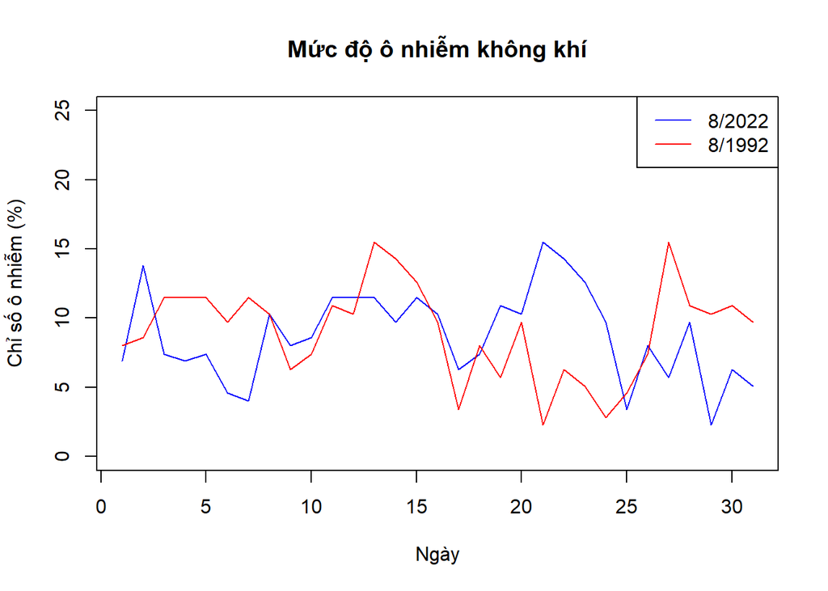

```r
# Plotting line chart

plot(POLLUTION ~ Day, # Thể hiện trục Y là pollution, trục X là ngày
  ok_1, # Lấy dữ liệu từ data frame ok_1 năm 2022
  col = "blue", # Màu sắc cho đường là xanh dương
  type = "l", # Thể hiện loại line chart
  xlab = "Ngày", # Tên của trục X
  ylab = "Chỉ số ô nhiễm (%)", # Tên của trục Y
  ylim = c(0, 25), # Giới hạn của trục Y
  main = "Mức độ ô nhiễm không khí" # Tiêu đề đồ thị
)

# Đưa thêm dữ liệu từ ok_2 năm 1992
points(POLLUTION ~ Day,
  ok_2,
  col = "red",
  type = "l",
  ylim = c(0, 30)
)

# Tạo bảng chú thích
legend("topright", # Vị trí của bảng
  lty = 1, # Tạo viền cho bảng
  col = c("blue", "red"), # Chú thích màu
  legend = c("8/2022", "8/1992"), # Ghi chú
  cex = 1 # Độ lớn font chữ
)
```

## Bar chart

So sánh mức độ ô nhiễm trong ngày 15 ở các tháng 8 đến 12 trong năm 2022 và 1992 qua đồ thị cột.

**Bước 1: Sắp xếp dữ liệu**

```r
# Lọc dữ liệu theo yêu cầu đề bài
ok_3 <- filter_theo_ngay_thang_final(ngay = 15, thang = 8:12, chat_luong_khong_khi_2022)
ok_4 <- filter_theo_ngay_thang_final(ngay = 15, thang = 8:12, chat_luong_khong_khi_1992)

# Xử lý dữ liệu ok_3 và ok_4 vào cùng 1 data frame

ok_3_2022 <- ok_3[ , c(3, 5)]
colnames(ok_3_2022) <- c(2022, "Month")

ok_4_1992 <- ok_4[ , c(3, 5)]
colnames(ok_4_1992) <- c(1992, "Month")

barplot_data <- cbind(ok_3_2022[1], ok_4_1992[1])

rownames(barplot_data) <- c("tháng 8", "tháng 9", "tháng 10", "tháng 11", "tháng 12")

barplot_data <- as.matrix(barplot_data) # Chuyển qua dạng matrix

# Kiểm tra data frame dùng để vẽ đồ thị
print(barplot_data)
```

```
##          2022 1992
## tháng 8  11.5 12.6
## tháng 9  13.8 16.6
## tháng 10 12.0 10.3
## tháng 11  8.0  5.1
## tháng 12 17.0 11.5
```

**Bước 2: Vẽ đồ thị**

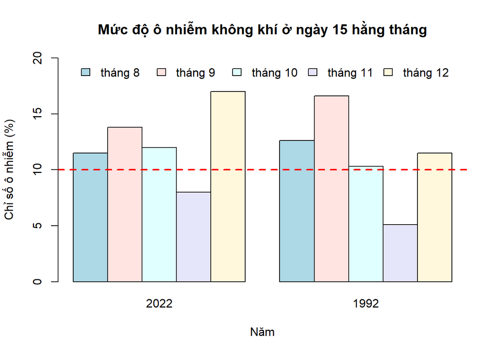

```r
# Define a set of colors
my_colors <- c("lightblue", "mistyrose", "lightcyan", "lavender", "cornsilk")

# Bar plot
barplot(barplot_data, # Đồ thị cột sử dụng data dạng matrix thay vì data frame
  col = my_colors,
  beside = TRUE, # Đặt các cột từng năm cạnh nhau
  ylim = c(0, 20),
  xlab = "Năm",
  ylab = "Chỉ số ô nhiễm (%)",
  main = "Mức độ ô nhiễm không khí ở ngày 15 hằng tháng"
)

# Add legend
legend("top",
  legend = rownames(barplot_data),
  horiz = TRUE,
  fill = my_colors,
  box.lty = 0,
  cex = 1
)

# Đưa đường baseline cảnh báo mức độ ô nhiễm
abline(h = 10, col = "red", lty = 2, lwd = 2)
```

## Boxplot

Đánh giá trung bình mức độ ô nhiễm trong các tháng 4, 5, 6 giữa hai năm 2022 và 1992, thể hiện phân bố ô nhiễm của các ngày quan trắc ở dạng đồ thị hộp.

**Bước 1: Sắp xếp dữ liệu**

```r
# Lọc dữ liệu theo yêu cầu đề bài
ok_5 <- filter_theo_ngay_thang_final(, thang = 4:6, chat_luong_khong_khi_2022)

ok_6 <- filter_theo_ngay_thang_final(, thang = 4:6, chat_luong_khong_khi_1992)
```

**Bước 2: Vẽ đồ thị**

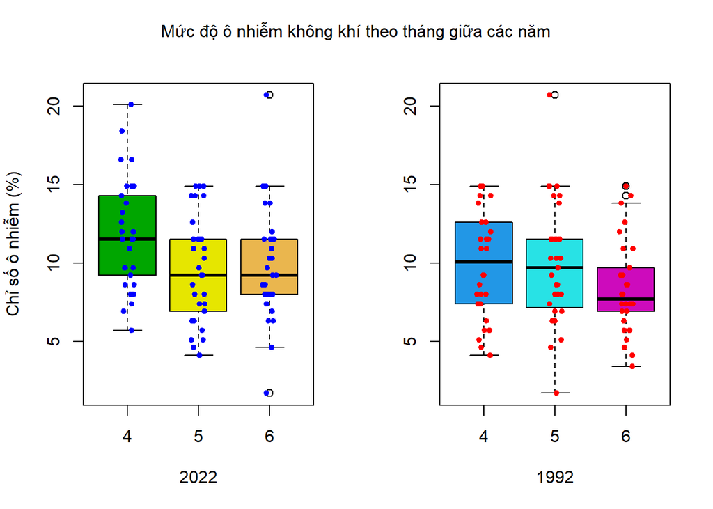

```r
# Tạo khung cho 2 đồ thị
old.par <- par(mfrow = c(1, 2))

boxplot(POLLUTION ~ Month, # Vẽ đồ thị cho năm 2022
  data = ok_5,
  lwd = 1,
  ylab = "Chỉ số ô nhiễm (%)",
  xlab = "2022",
  col = terrain.colors(5) # Chọn dãy màu
)

stripchart(POLLUTION ~ Month,
  vertical = TRUE,
  data = ok_5,
  method = "jitter", # Thể hiện data point năm 2022
  add = TRUE,
  pch = 20,
  col = "blue"
)

boxplot(POLLUTION ~ Month, # Vẽ đồ thị cho năm 1992
  data = ok_6,
  lwd = 1,
  ylab = NULL,
  xlab = "1992",
  col = 4:6
)

stripchart(POLLUTION ~ Month,
  vertical = TRUE,
  data = ok_6,
  method = "jitter", # Thể hiện data point năm 1992
  add = TRUE,
  pch = 20,
  col = "red"
)

# Tạo tiêu đề chung cho 2 đồ thị
mtext("Mức độ ô nhiễm không khí theo tháng giữa các năm",
  side = 3,
  line = -2,
  outer = TRUE
)
```

```r
# Tắt khung cho 2 đồ thị
par(old.par)
```

### Sơ kết

Trên đây là ví dụ minh họa cho bài giảng *Cách xây dựng hàm số* trong **khóa học “HDSD R để xử lý dữ liệu | Chuyên đề Coding in R”**, **sau 20 giờ học, bạn sẽ có nền tảng vững chắc về R căn bản và cách xây dựng function cho riêng mình!**

**Nội dung khóa học: `www.tuhocr.com`**

**Hành trình ngàn dặm bắt đầu từ bước chân đầu tiên.**

**ĐĂNG KÝ NGAY: `https://www.tuhocr.com/register`**

[figure not shown]